# Regression

11/30/2018

## Load in ur stuff!

```r
library(ggplot2)
library(dplyr)
lion <- read.csv("LionAge.csv")
head(lion)
```

|  | age | proportion.black |
| --- | --- | --- |
| 1 | 1.1 | 0.21 |
| 2 | 1.5 | 0.14 |
| 3 | 1.9 | 0.11 |
| 4 | 2.2 | 0.13 |
| 5 | 2.6 | 0.12 |
| 6 | 3.2 | 0.13 |

## Plan for today

- Setting up a regression model with `lm()`
- Checking your regression assumptions
  - Residuals plots
  - Normal probability plots
- Doing a regression test with `summary()`
- Plotting best-fit lines with `geom_smooth()`

## A review of correlation

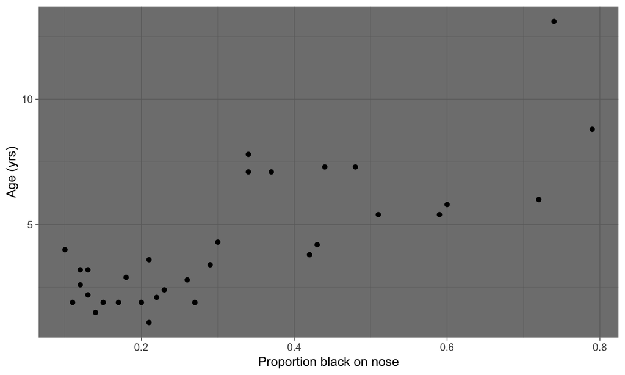

```r
ggplot(lion, aes(x = proportion.black, y = age)) +
  geom_point() + theme_dark() + labs(x = "Proportion black on nose", y = "Age (yrs)")
```

## A review of correlation

```r
cor <- cor.test(lion$proportion.black, lion$age, method = "pearson")
cor$estimate #Pearson correlation coefficient
```

```
##       cor
## 0.7898272
```

```r
cor$estimate^2 #R-squared
```

```
##      cor
## 0.623827
```

## Setting up a regression model with `lm()`

\(Y = \alpha + \beta*X\)

```r
lion.model <- lm(age ~ proportion.black, data = lion) #lm stands for linear model
lion.model
```

```
##
## Call:
## lm(formula = age ~ proportion.black, data = lion)
##
## Coefficients:
##      (Intercept)  proportion.black
##            0.879            10.647
```

## Setting up a regression model with `lm()`

Make your own regression model!

See if you can predict tree girth as a function of tree height

## Setting up a regression model with `lm()`

Make your own regression model!

```r
tree.model = lm(Girth ~ Height, data = trees)
tree.model
```

```
##
## Call:
## lm(formula = Girth ~ Height, data = trees)
##
## Coefficients:
## (Intercept)       Height
##     -6.1884       0.2557
```

## Checking your regression assumptions (17.5)

1. LINEARITY: a true linear relationship between \(X\) and \(Y\) in the underlying population, such that \(Y = \alpha + \beta*X\)
2. NORMALITY: at every value of \(X\), \(Y\) is normally distributed
3. VARIANCE: at each value of \(X\), the variance of \(Y\) is equal

## Residuals plots

## Checking your regression assumptions

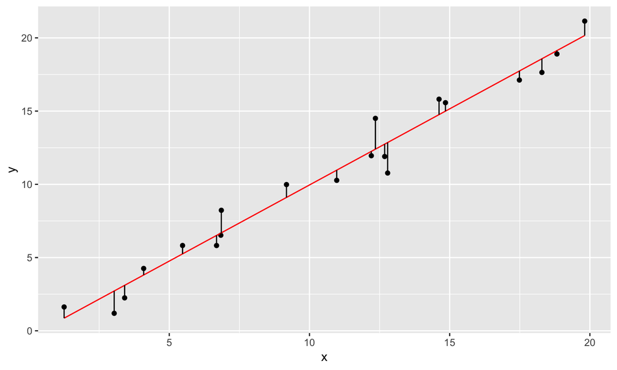

## Checking your regression assumptions

```r
fortify(lion.model)
```

|  | age | proportion.black | .hat | .sigma | .cooksd | .fitted | .resid | .stdresid |
| --- | --- | --- | --- | --- | --- | --- | --- | --- |
| 1 | 1.1 | 0.21 | 0.04154830 | 1.653704 | 3.296860e-02 | 3.114901 | -2.01490129 | -1.23331413 |
| 2 | 1.5 | 0.14 | 0.05840900 | 1.689114 | 8.944936e-03 | 2.369603 | -0.86960293 | -0.53702548 |
| 3 | 1.9 | 0.11 | 0.06808971 | 1.697046 | 3.175350e-04 | 2.050189 | -0.15018934 | -0.09323031 |
| 4 | 2.2 | 0.13 | 0.06147226 | 1.697249 | 4.994137e-05 | 2.263132 | -0.06313173 | -0.03905073 |
| 5 | 2.6 | 0.12 | 0.06469916 | 1.695156 | 2.610050e-03 | 2.156661 | 0.44333946 | 0.27470450 |
| 6 | 3.2 | 0.13 | 0.06147226 | 1.687765 | 1.099821e-02 | 2.263132 | 0.93686827 | 0.57950878 |
| 7 | 3.2 | 0.12 | 0.06469916 | 1.685428 | 1.445531e-02 | 2.156661 | 1.04333946 | 0.64647989 |
| 8 | 2.9 | 0.18 | 0.04779243 | 1.697176 | 1.033739e-04 | 2.795488 | 0.10451230 | 0.06418102 |
| 9 | 2.4 | 0.23 | 0.03820378 | 1.688175 | 6.383662e-03 | 3.327844 | -0.92784368 | -0.56694160 |
| 10 | 2.1 | 0.22 | 0.03979421 | 1.683936 | 9.744761e-03 | 3.221372 | -1.12137248 | -0.68576100 |

[output cut: 22 more lines]

## Checking your regression assumptions

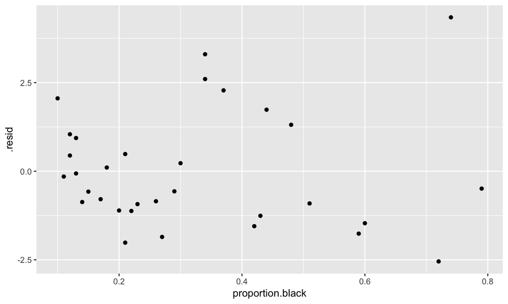

```r
ggplot(fortify(lion.model), aes(x = proportion.black, y = .resid)) +
  geom_point()
```

## Checking your regression assumptions

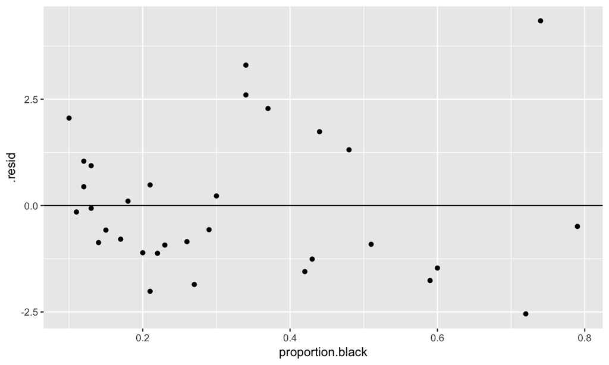

```r
ggplot(fortify(lion.model), aes(x = proportion.black, y = .resid)) +
  geom_point() + geom_hline(yintercept = 0)
```

## Checking your regression assumptions

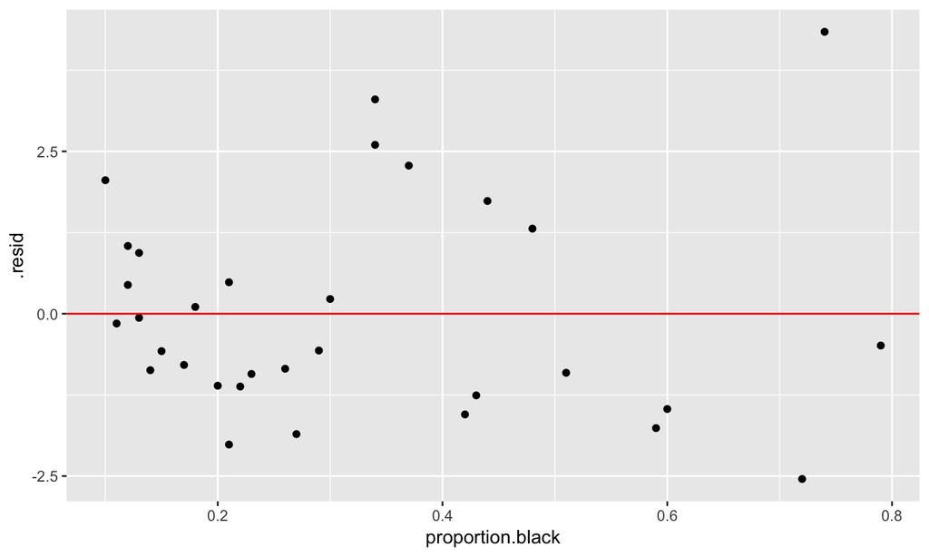

```r
ggplot(fortify(lion.model), aes(x = proportion.black, y = .resid)) +
  geom_point() + geom_hline(yintercept = 0, color = "red")
```

## Checking your regression assumptions

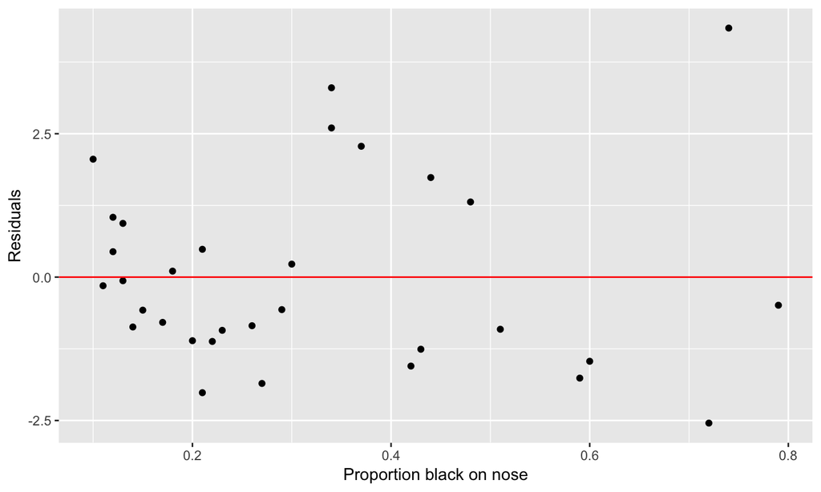

```r
ggplot(fortify(lion.model), aes(x = proportion.black, y = .resid)) +
  geom_point() + geom_hline(yintercept = 0, color = "red") +
  labs(x = "Proportion black on nose", y = "Residuals")
```

## Checking your regression assumptions

Check the assumptions of your regression model with a plot of your own!

## Checking your regression assumptions

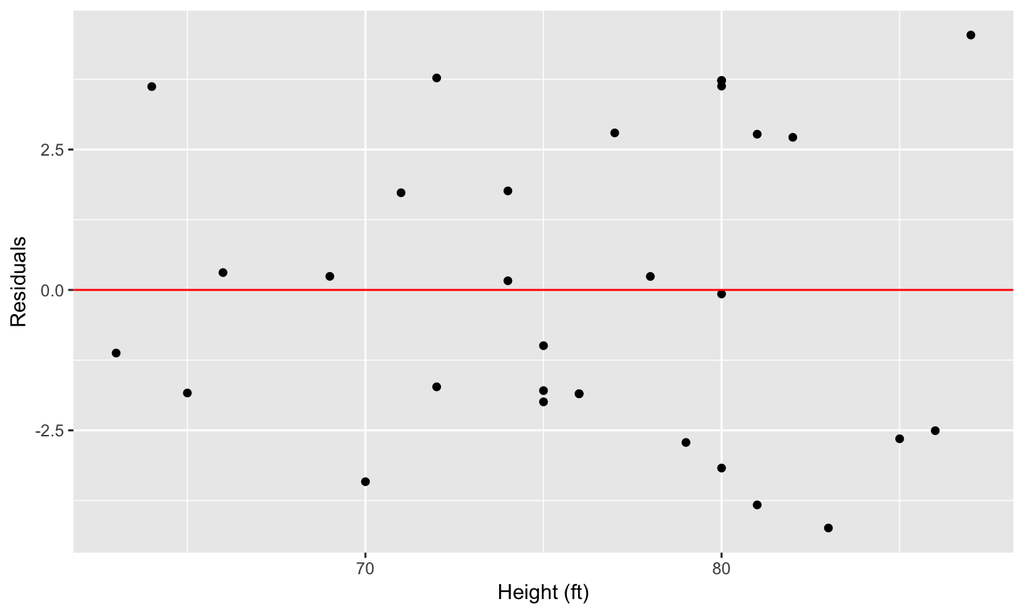

```r
ggplot(tree.model, aes(x = Height, y = .resid)) +
  geom_point() + geom_hline(yintercept = 0, color = "red") +
  labs(x = "Height (ft)", y = "Residuals")
```

## Normal probability plots

## Checking your regression assumptions

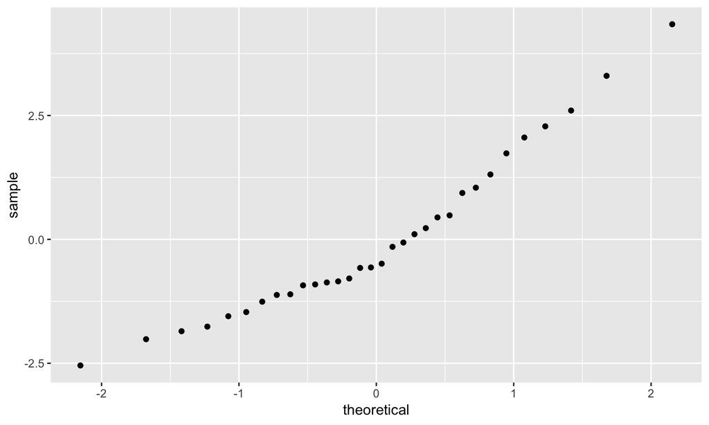

```r
ggplot(fortify(lion.model), aes(sample = .resid)) +
  geom_qq()
```

## Checking your regression assumptions

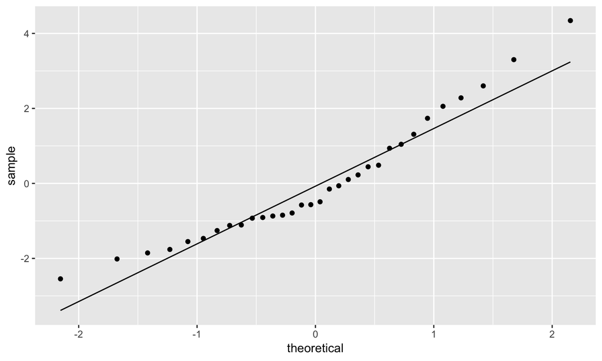

```r
ggplot(fortify(lion.model), aes(sample = .resid)) +
  geom_qq() + geom_qq_line()
```

## Checking your regression assumptions

```r
ggplot(fortify(lion.model), aes(sample = .resid)) +
  geom_qq() + geom_qq_line() +  coord_flip()
```

[output not shown]

## Checking your regression assumptions

Check the assumptions of your regression model with a plot of your own!

## Checking your regression assumptions

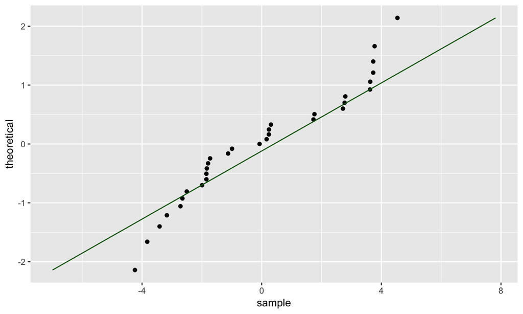

```r
ggplot(tree.model, aes(sample = .resid)) +
  geom_qq() + geom_qq_line(color = "darkgreen") + coord_flip()
```

## Checking your regression assumptions

```r
ggplot(fortify(lion.model), aes(sample = .resid)) +
  geom_qq() + geom_qq_line() + coord_flip()
```

[output not shown]

## Transforming your data

```r
lion.2 <- lion %>% mutate(age.2 = log(age))
lion.2
```

| age | proportion.black | age.2 |
| --- | --- | --- |
| 1.1 | 0.21 | 0.09531018 |
| 1.5 | 0.14 | 0.40546511 |
| 1.9 | 0.11 | 0.64185389 |
| 2.2 | 0.13 | 0.78845736 |
| 2.6 | 0.12 | 0.95551145 |
| 3.2 | 0.13 | 1.16315081 |
| 3.2 | 0.12 | 1.16315081 |
| 2.9 | 0.18 | 1.06471074 |
| 2.4 | 0.23 | 0.87546874 |
| 2.1 | 0.22 | 0.74193734 |

[output cut: 22 more lines]

## Transforming your data

```r
lion.king.2 <- lm(age.2 ~ proportion.black, data = lion.2) #lm stands for linear model
lion.king.2
```

```
##
## Call:
## lm(formula = age.2 ~ proportion.black, data = lion.2)
##
## Coefficients:
##      (Intercept)  proportion.black
##            0.545             2.308
```

## Re-checking your regression assumptions

```r
ggplot(fortify(lion.model), aes(sample = .resid)) +
  geom_qq() + geom_qq_line() + coord_flip()
```

[output not shown]

## Re-checking your regression assumptions

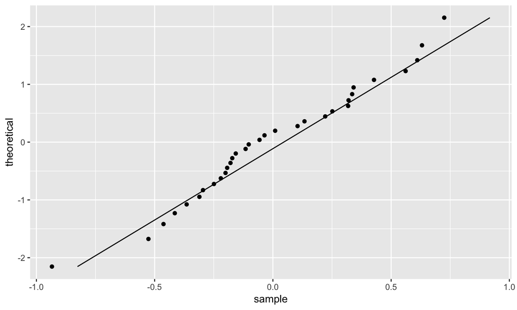

```r
ggplot(fortify(lion.king.2), aes(sample = .resid)) +
  geom_qq() + geom_qq_line() + coord_flip()
```

## Doing a regression test with `summary()`

```r
summary(lion.model)
```

```
##
## Call:
## lm(formula = age ~ proportion.black, data = lion)
##
## Residuals:
##     Min      1Q  Median      3Q     Max
## -2.5449 -1.1117 -0.5285  0.9635  4.3421
##
## Coefficients:
##                  Estimate Std. Error t value Pr(>|t|)
## (Intercept)        0.8790     0.5688   1.545    0.133
## proportion.black  10.6471     1.5095   7.053 7.68e-08 ***
## ---
## Signif. codes:  0 '***' 0.001 '**' 0.01 '*' 0.05 '.' 0.1 ' ' 1
##
## Residual standard error: 1.669 on 30 degrees of freedom
## Multiple R-squared:  0.6238, Adjusted R-squared:  0.6113
## F-statistic: 49.75 on 1 and 30 DF,  p-value: 7.677e-08
```

## Doing a regression test with `summary()`

```r
summary(lion.king.2)
```

```
##
## Call:
## lm(formula = age.2 ~ proportion.black, data = lion.2)
##
## Residuals:
##      Min       1Q   Median       3Q      Max
## -0.93427 -0.22742 -0.07936  0.31862  0.72453
##
## Coefficients:
##                  Estimate Std. Error t value Pr(>|t|)
## (Intercept)        0.5450     0.1323   4.118 0.000276 ***
## proportion.black   2.3078     0.3512   6.572 2.86e-07 ***
## ---
## Signif. codes:  0 '***' 0.001 '**' 0.01 '*' 0.05 '.' 0.1 ' ' 1
##
## Residual standard error: 0.3882 on 30 degrees of freedom
## Multiple R-squared:  0.5901, Adjusted R-squared:  0.5764
## F-statistic: 43.19 on 1 and 30 DF,  p-value: 2.856e-07
```

## FYI…

## FYI…

You can also perform a regression test on a linear model with `anova()`

```r
anova(lion.king.2)
```

```
## Analysis of Variance Table
##
## Response: age.2
##                  Df Sum Sq Mean Sq F value    Pr(>F)
## proportion.black  1 6.5089  6.5089  43.186 2.856e-07 ***
## Residuals        30 4.5216  0.1507
## ---
## Signif. codes:  0 '***' 0.001 '**' 0.01 '*' 0.05 '.' 0.1 ' ' 1
```

## FYI…

You can calculate 95% confidence intervals for the slope using `confint()`

```r
confint(lion.king.2)
```

```
##                     2.5 %    97.5 %
## (Intercept)      0.274696 0.8152074
## proportion.black 1.590581 3.0249654
```

## Doing a regression test with `summary()`

Do a regression test of your own on your regression model!

Use the coefficients from the model to write the linear equation

## Doing a regression test with `summary()`

```r
summary(tree.model)
```

```
##
## Call:
## lm(formula = Girth ~ Height, data = trees)
##
## Residuals:
##     Min      1Q  Median      3Q     Max
## -4.2386 -1.9205 -0.0714  2.7450  4.5384
##
## Coefficients:
##             Estimate Std. Error t value Pr(>|t|)
## (Intercept) -6.18839    5.96020  -1.038  0.30772
## Height       0.25575    0.07816   3.272  0.00276 **
## ---
## Signif. codes:  0 '***' 0.001 '**' 0.01 '*' 0.05 '.' 0.1 ' ' 1
##
## Residual standard error: 2.728 on 29 degrees of freedom
## Multiple R-squared:  0.2697, Adjusted R-squared:  0.2445
## F-statistic: 10.71 on 1 and 29 DF,  p-value: 0.002758
```